# Data Visualization Tutorial

# Introduction

Visualizing your data is hands down the most important thing you can learn to do. Please review the resources linked at the end of this document for additional learning resources.

There are two audiences in mind when creating data visualizations:

1. For your eyes only. These are quick and dirty plots, without annotation. Meant to be looked at once or twice.
2. To share with others. These need to completely stand on their own. Axes labels, titles, colors as needed, possibly captions.

You will see, and slowly learn, how to add these annotations and how to clean up your graphics to make them sharable. `ggplot2` already does a lot of this work for you.

We will also use the two most common methods used to create plots. 1) Base graphics, 2) the `ggplot2` package. We will not cover `lattice` graphics in this lab but they are worth looking into.

For **almost** every plot discussed we will create the plot using first base graphics, then using `ggplot2`. Each have their own advantages and disadvantges. If you have not done so already, go ahead and install the `ggplot2` package now.

# The Data

We will use a subset of the `diamonds` dataset that comes with the `ggplot2` package. This dataset contains the prices and other attributes of almost 54,000 diamonds. Review `?diamonds` to learn about the variables we will be using.

```r
library(ggplot2)
data("diamonds")
set.seed(1410) # Make the sample reproducible
dsmall <- diamonds[sample(nrow(diamonds), 1000), ]
```

# One Categorical variable

## Barcharts / Barplots

#### Base Graphics

To create a barplot/barchart in base graphics requires the data to be in summarized in a table form first. Then the result of the table is plotted. The first argument is the table to be plotted, the `main` argument controls the title.

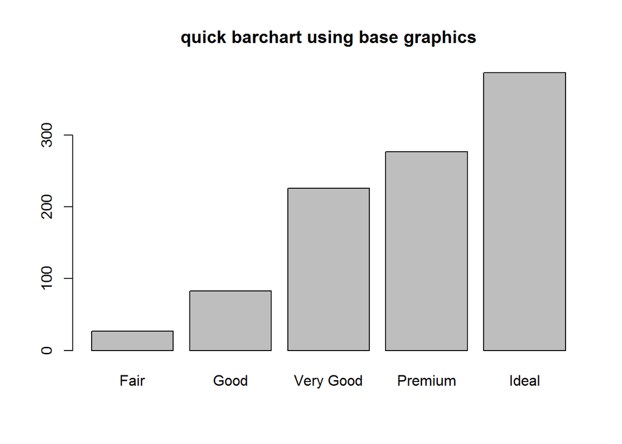

```r
dc <- table(dsmall$cut)
barplot(dc, main="quick barchart using base graphics")
```

#### ggplot

ggplot’s “quick” plotting method uses the function `qplot()`. The syntax is pretty standard across plot type. You specify what you want plotted along the `x` axis, the `y` axis (optional depending on the type of plot), what geometric shape, or `geom` you want, the `data` set name, and a title using `main`.

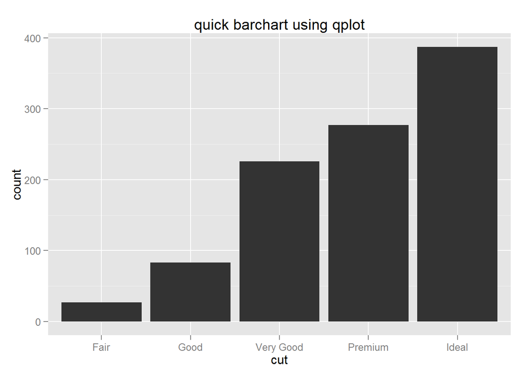

```r
qplot(x=cut, data=dsmall, geom="bar", main="quick barchart using qplot")
```

When you need something a little more detailed however, you will have to use the `ggplot()` function. It has similar type of arguments but is presented in a different manner. The generic syntax is built up in a stepwise fashion using `+` symbols to “add on” features to the plot.

So first you specify what data set you’re using, then the aestetic `aes()`, this is where you specify the main plotting variables.

```r
ggplot(dsmall, aes(x=cut))
```

```
## Error: No layers in plot
```

This error message is present because no `geom`’s have been specified. That’s where the `geom_bar()` comes in. Note that it’s also a function that can take additional arguments. We’ll see how to use those later. Here is the `ggplot()` version of the barchart.

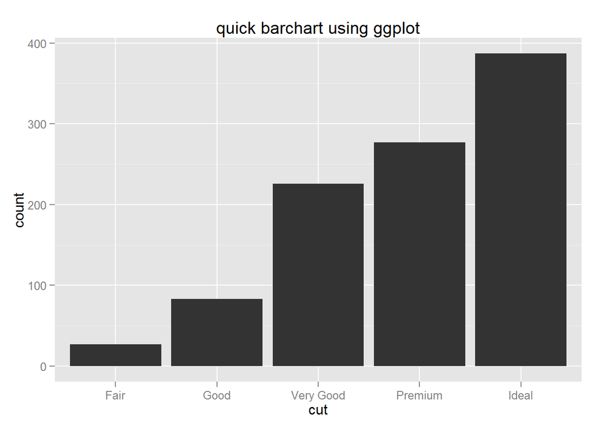

```r
ggplot(dsmall, aes(x=cut)) +
  geom_bar() + ggtitle("quick barchart using ggplot")
```

And we’ll finish off with a presentable version of this plot.

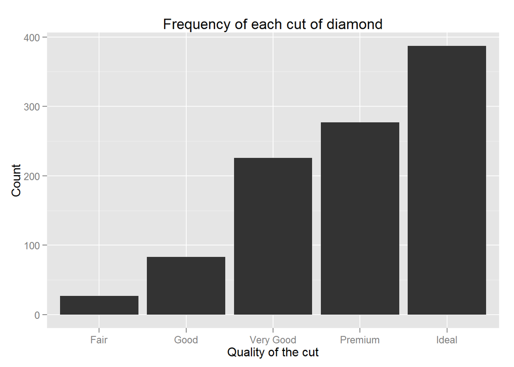

```r
ggplot(dsmall, aes(x=cut)) + geom_bar() + ggtitle("Frequency of each cut of diamond") +
  xlab("Quality of the cut") + ylab("Count")
```

# Two Categorical variables

### Grouped bar charts

To compare proprtions of one categorical variable within the same level of another, is to use grouped barcharts.

#### Base Graphics

As before, the object to be plotted needs to be the result of a table. The `beside=TRUE` is what controls the placement of the bars.

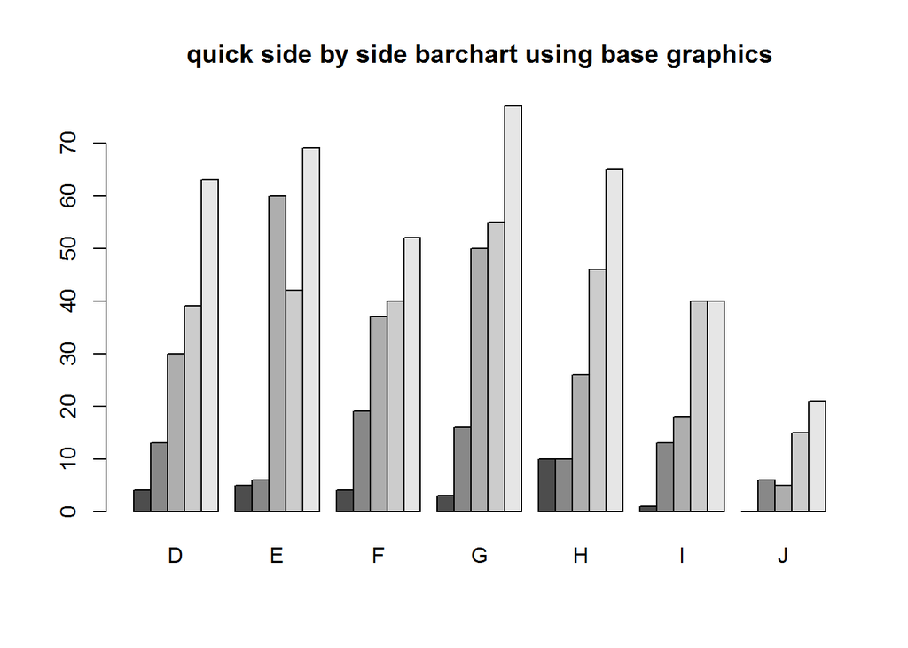

```r
cc <- table(dsmall$cut, dsmall$color)
barplot(cc, main="quick side by side barchart using base graphics", beside=TRUE)
```

Great, but what do the colors represent? We need to add a legend. And i’m going to customize the colors.

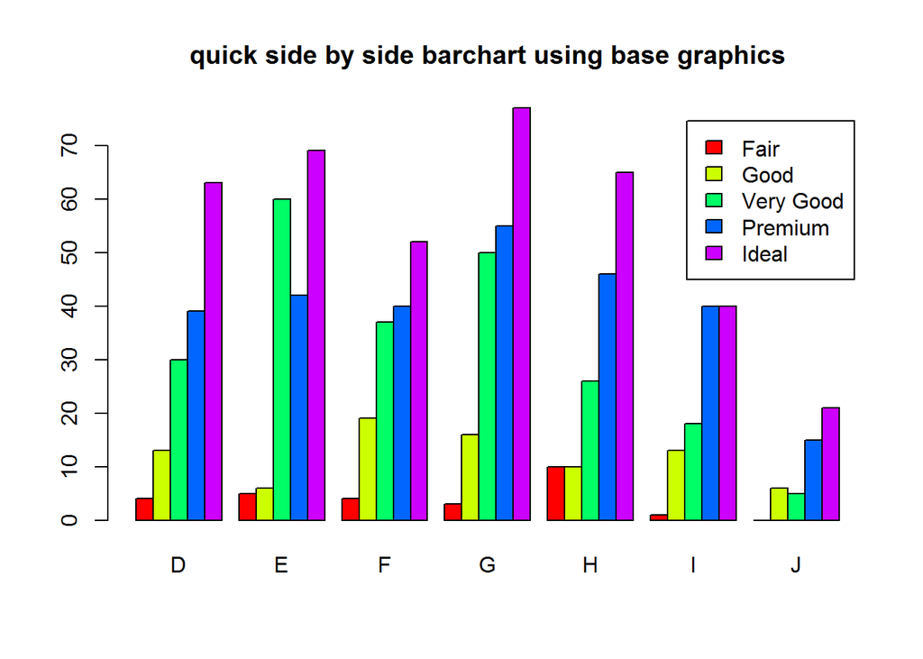

```r
barplot(cc, main="quick side by side barchart using base graphics", beside=TRUE,
        col=rainbow(5), legend=rownames(cc))
```

For more than 2 colors I do not recommend choosing the colors yourself. I know little about color theory so I use the built-in color palettes. Here is a [great cheatsheet](https://www.nceas.ucsb.edu/~frazier/RSpatialGuides/colorPaletteCheatsheet.pdf) about using color palettes.

#### ggplot

Again starting by using `qplot()` but this time we’ll `fill` using the second categorical variable.

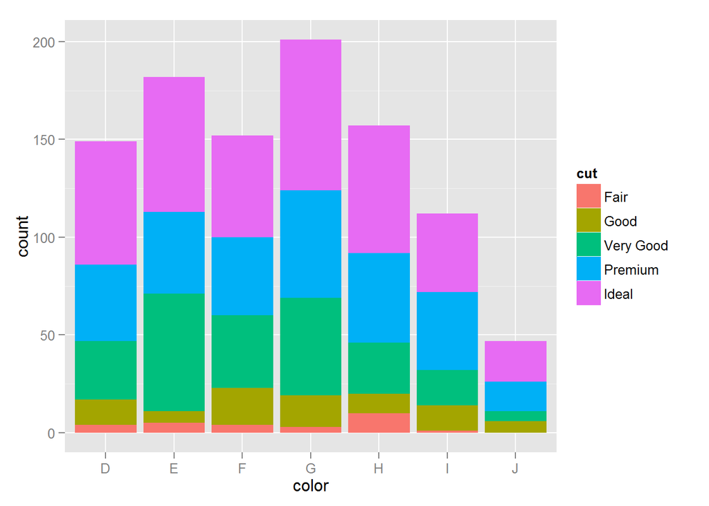

```r
qplot(x=color, fill=cut, data=dsmall)
```

The colors are stacked! I **highly discourage** the use of this type of plot. You can compare across colors how many are fair, but after that it becomes to difficult to compare. What color has more ideal cuts, F or G? So we just specify `position=dodge` to put the bars side by side.

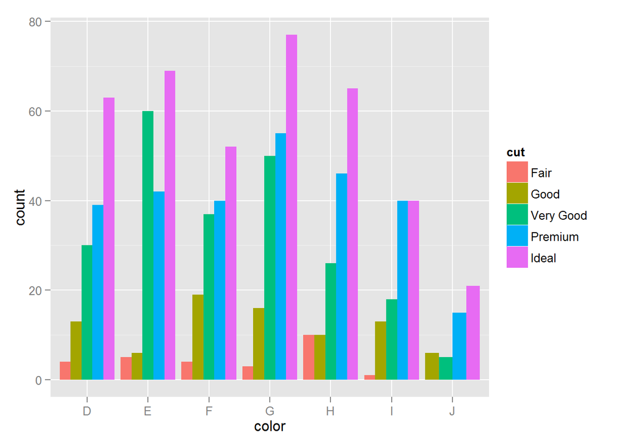

```r
qplot(x=color, fill=cut, data=dsmall, position="dodge")
```

And look, an automatic legend. But what if I wanted to better compare color across cut? It’s hard to compare individual bars across the groups. Just switch which variable is the x axis and which one is used to fill the colors!

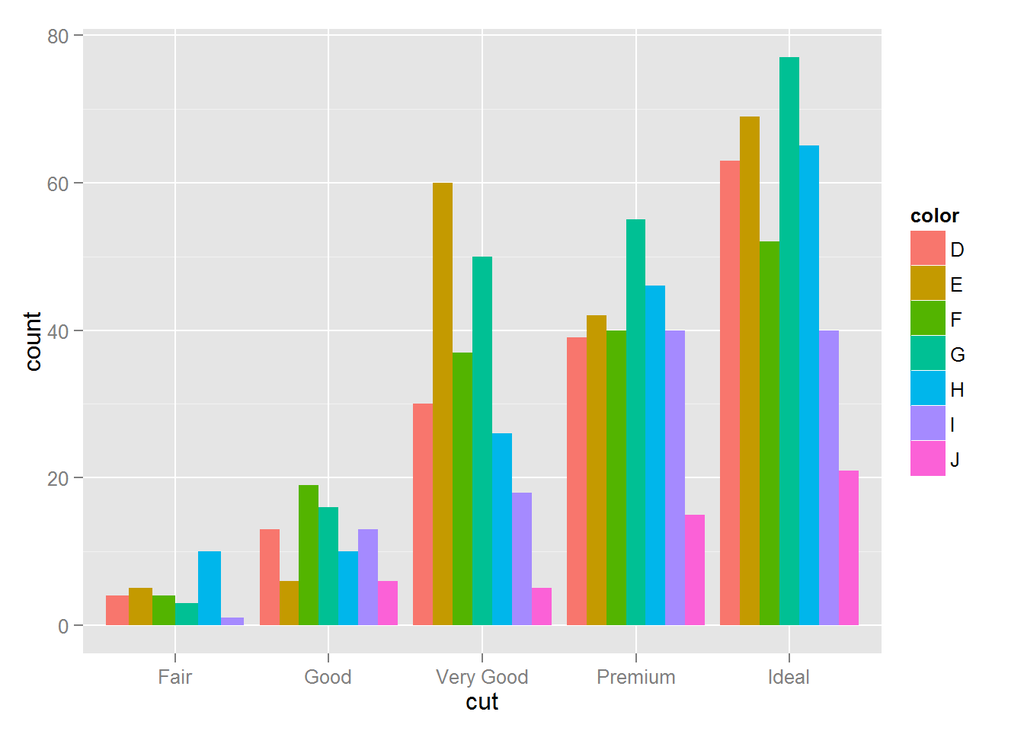

```r
qplot(x=cut, fill=color, data=dsmall, position="dodge")
```

### Mosaic plots

But what if you want to know how two categorical variables are related and you don’t want to look at two different barplots? Mosaic plots are a way to visualize the proportions in a table. So here’s the two-way table we’ll be plotting.

```r
table(dsmall$cut, dsmall$color)
```

```
##
##              D  E  F  G  H  I  J
##   Fair       4  5  4  3 10  1  0
##   Good      13  6 19 16 10 13  6
##   Very Good 30 60 37 50 26 18  5
##   Premium   39 42 40 55 46 40 15
##   Ideal     63 69 52 77 65 40 21
```

The syntax for a mosiac plot uses *model notation*, which is basically y ~ x where the ~ is read as “twiddle” or “tilde”. It’s to the left of your **1** key.

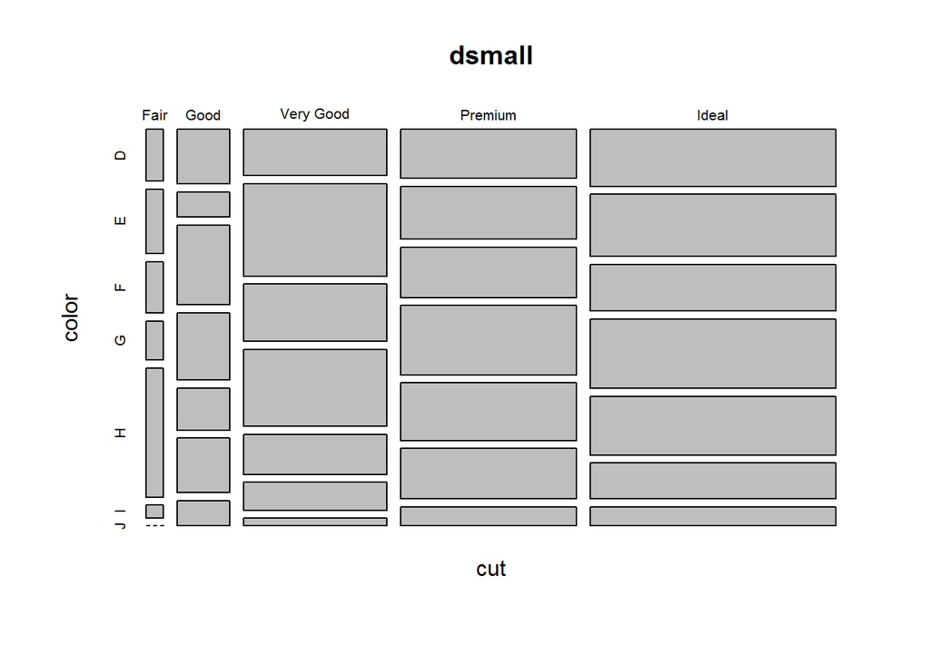

```r
mosaicplot(cut~color, data=dsmall)
```

Helpful, ish. Here are two very useful options. In reverse obviousness, `color` applies shades of gray to one of the factor levels, and `shade` applies a color gradient scale to the cells in order of what is less than expected (red) to what is more than expected (blue) if these two factors were compltely independent.

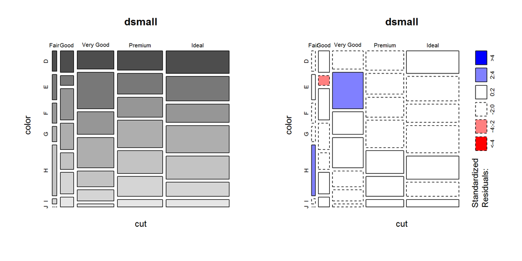

```r
par(mfrow=c(1,2)) # display the plots in 1 row and 2 columns
mosaicplot(cut~color, data=dsmall, color=TRUE)
mosaicplot(cut~color, data=dsmall, shade=TRUE)
```

That’s about all the ways you can plot categorical variables. If you are wondering why there was no pie charts or 3D barcharts demonstrated see [here](http://www.businessinsider.com/pie-charts-are-the-worst-2013-6), and [here](https://blogs.oracle.com/experience/entry/countdown_of_top_10_reasons_to_never_ever_use_a_pie_chart), or [here](http://faculty.atu.edu/mfinan/2043/section31.pdf), [here](http://www.bbc.co.uk/schools/gcsebitesize/maths/statistics/representingdata2rev5.shtml), and [here](https://en.wikipedia.org/wiki/Misleading_graph) for other ways you can really screw up your visualization.

# One Numeric variable

Numeric variables are ones that can be measured, these are also typically called continuous measurements. Here we can look at the price, carat, and depth of the diamonds.

#### Plot

The most basic of basics of plots, which sometimes can still be useful is to use the base R function `plot()`.

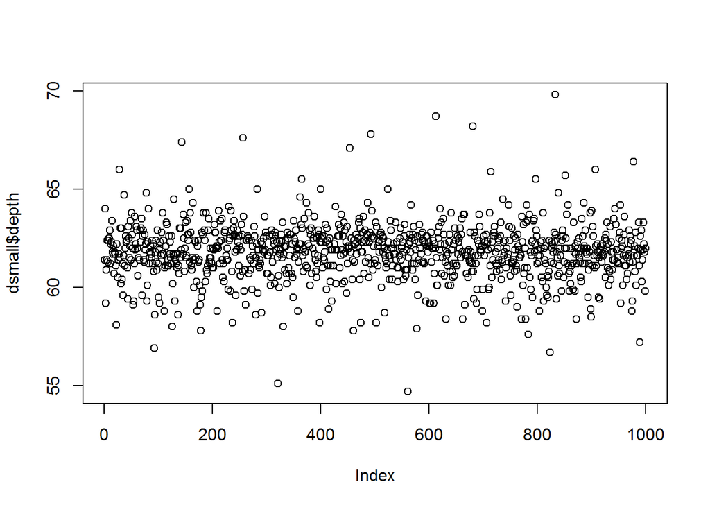

```r
plot(dsmall$depth)
```

The value of the variable is plotted on the y axis, and the index, or row number, is plotted on the x axis.

### Dotplot/stripchart

A dotplot or stripchart is the next most simplest plots and yet less informative. One point is plotted per observation, all are plotted on the same line.

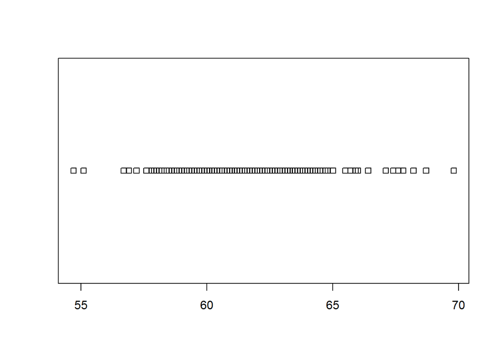

```r
stripchart(dsmall$depth)
```

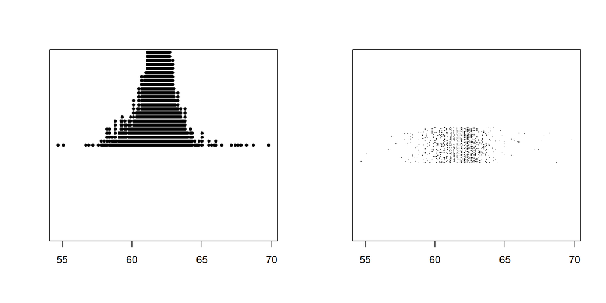

```r
par(mfrow=c(1,2))
stripchart(dsmall$depth, method="stack", pch=20)
stripchart(dsmall$depth, method="jitter", pch=".")
```

The `par(mfrow=c(1,2))` tells `R` to split the plotting region into 1 row and 2 columns. This is useful for displaying different plots side by side or stacked.

Remember the vertical axis doesn’t mean anything here. Univariate dotplots are not helpful to plot raw data. We’ll come back to them later.

All of those plots were made with base graphics.

#### ggplot

To plot the values of depth against the index you provide a value of 1 `y=1` to put all points on the same line, and use a `point` for the geom.

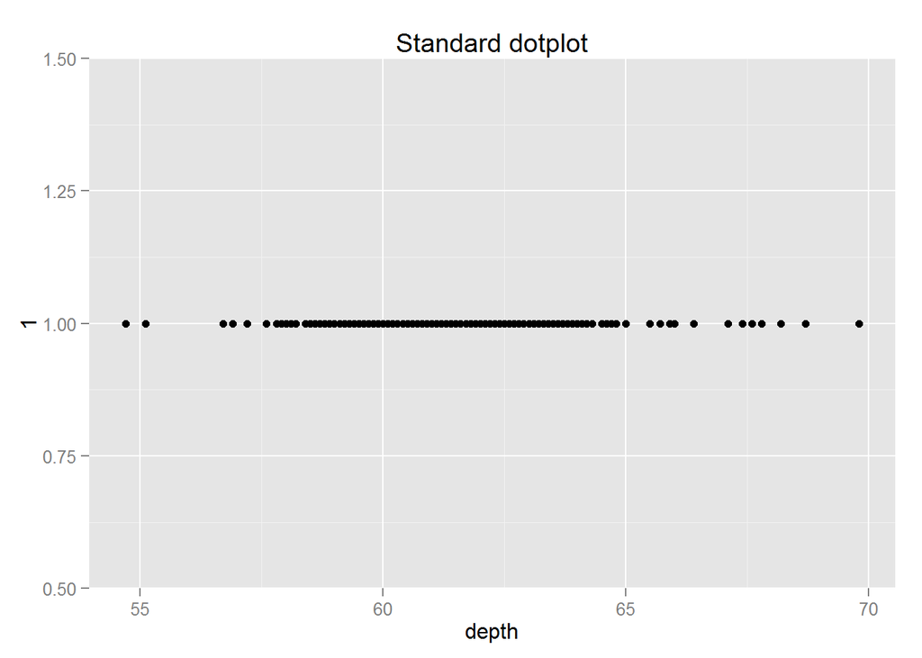

```r
qplot(y=1, x=depth, data=dsmall,  geom="point", main="Standard dotplot")
```

If we want to jitter or stack we can use the `position` argument.

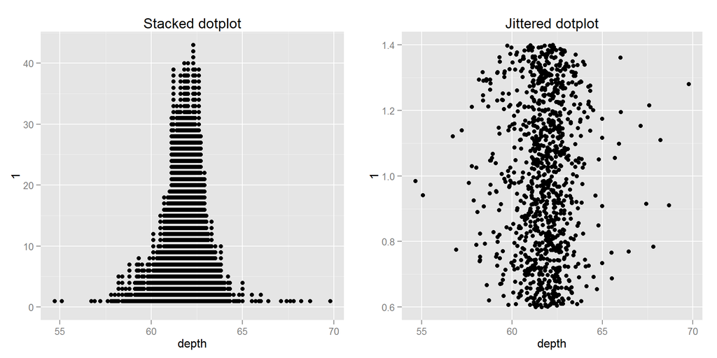

```r
library(gridExtra)
jitter <- qplot(y=1, x=depth, data=dsmall,  geom="point", position="jitter", main="Jittered dotplot")
stack <- qplot(y=1, x=depth, data=dsmall,  geom="point", position="stack", main="Stacked dotplot")
grid.arrange(stack, jitter, ncol=2)
```

The `gridExtra` package allows us to arrange multiple `ggplot` plots. It’s like the `mfrow()` statement in base graphics.

To get the exact same three plots (not shown) using `ggplot()` we can use the `geom_point()` with different `position =` arguments.

```r
ggplot(dsmall, aes(x=depth, y=1)) + geom_point() + ggtitle("Standard dotplot")
ggplot(dsmall, aes(x=depth, y=1)) + geom_point(position = position_stack()) +
       ggtitle("stacked dotplot")
ggplot(dsmall, aes(x=depth, y=1)) + geom_point(position = position_jitter()) +
       ggtitle("jittered dotplot")
```

### Histograms

In a histogram, the binned counts are plotted as bars into a histogram. Note that the x-axis is continuous, so the bars touch. This is unlike the barchart that has a categorical x-axis, and vertical bars that are separated.

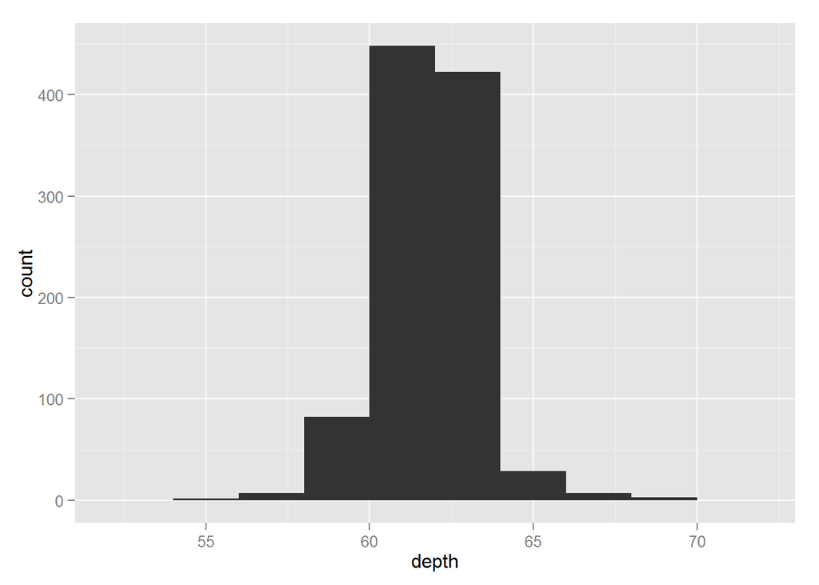

```r
qplot(x=depth, data=dsmall, geom="histogram", binwidth=2)
```

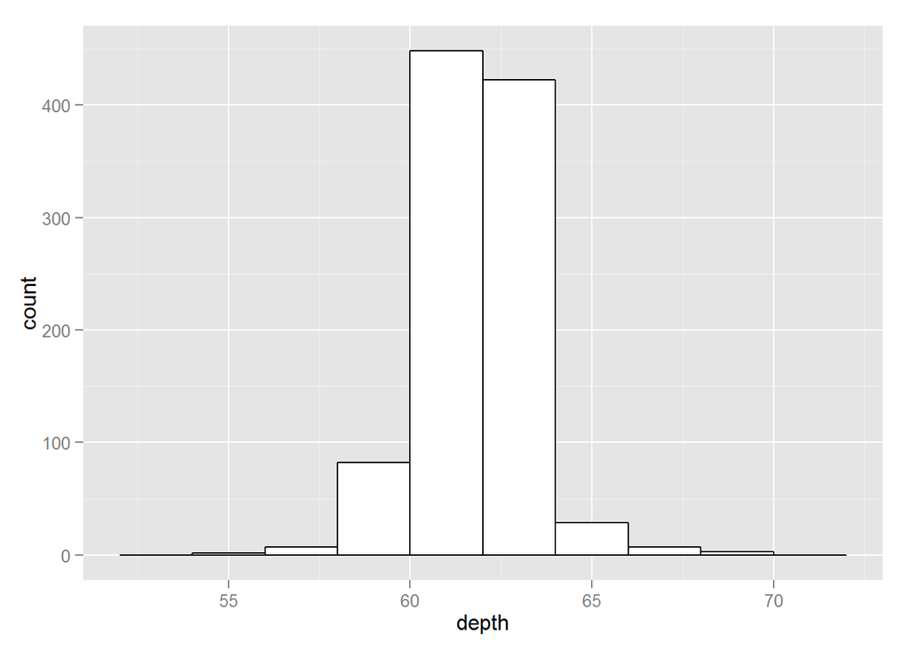

```r
qplot(x=depth, data=dsmall, geom="histogram", binwidth=2,
      color=I("black"), fill=I("white"))
```

For much more control over histograms, which we will need in the next section, we turn to the `ggplot()` function. We still specifiy the data set, the `aes`tetic is that we want depth on the `x` axis, and then add a `geom_histogram` that has black lines and the bars filled white.

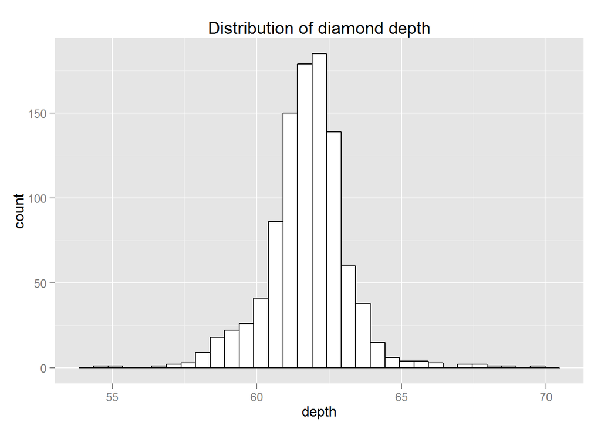

```r
ggplot(dsmall, aes(x=depth)) + geom_histogram(colour="black", fill="white") +
  ggtitle("Distribution of diamond depth")
```

Note I did **not** specify the `binwidth` argument here. The size of the bins can hide features from your graph, the default value for ggplot2 is range/30 and usually is a good choice.

#### Base graphics

But what about base graphics? You can make a histogram in base graphics super easy.

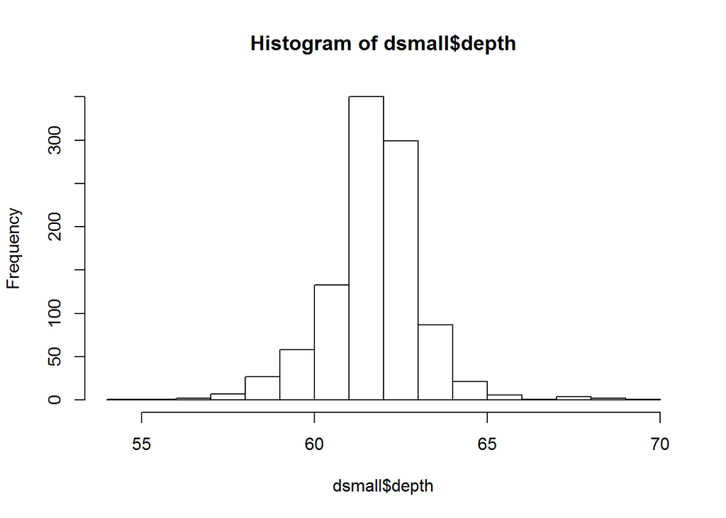

```r
hist(dsmall$depth)
```

And it doesn’t take too much to clean it up. Here you can specify the number of bins by specifying how many `breaks` should be made in the data and use `col` for the fill color.

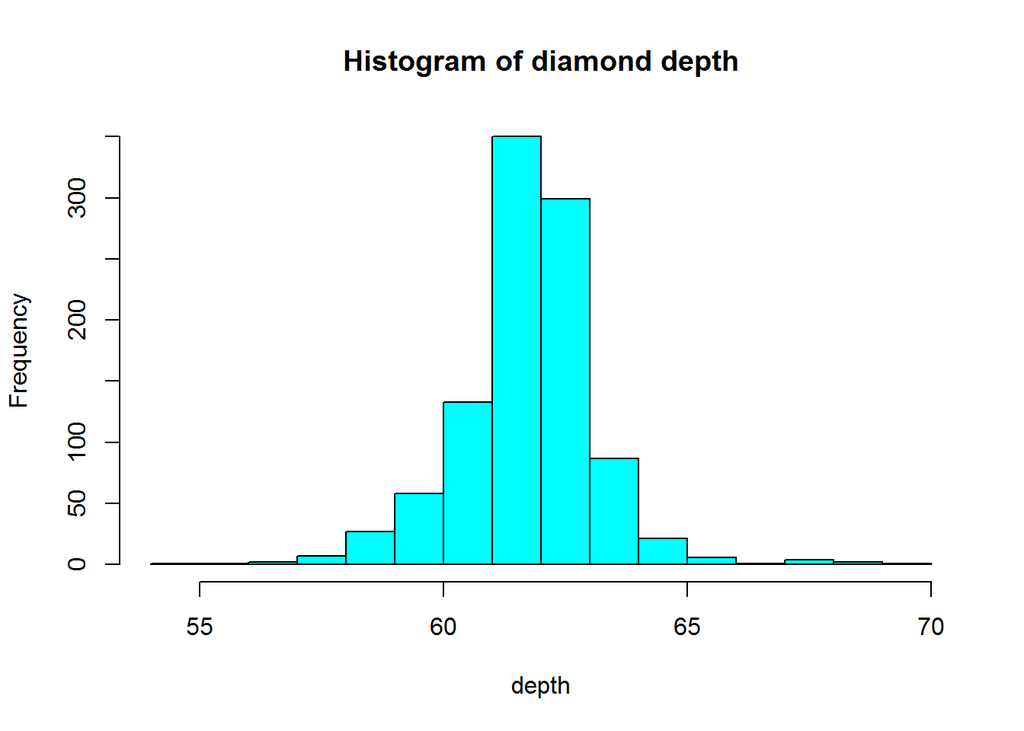

```r
hist(dsmall$depth, xlab="depth", main="Histogram of diamond depth", col="cyan", breaks=20)
```

### Density plots

To get a better idea of the true shape of the distribution we can “smooth” out the bins and create what’s called a `density` plot or curve. Notice that the shape of this distribution curve is much more… “wigglier” than the histogram may have implied.

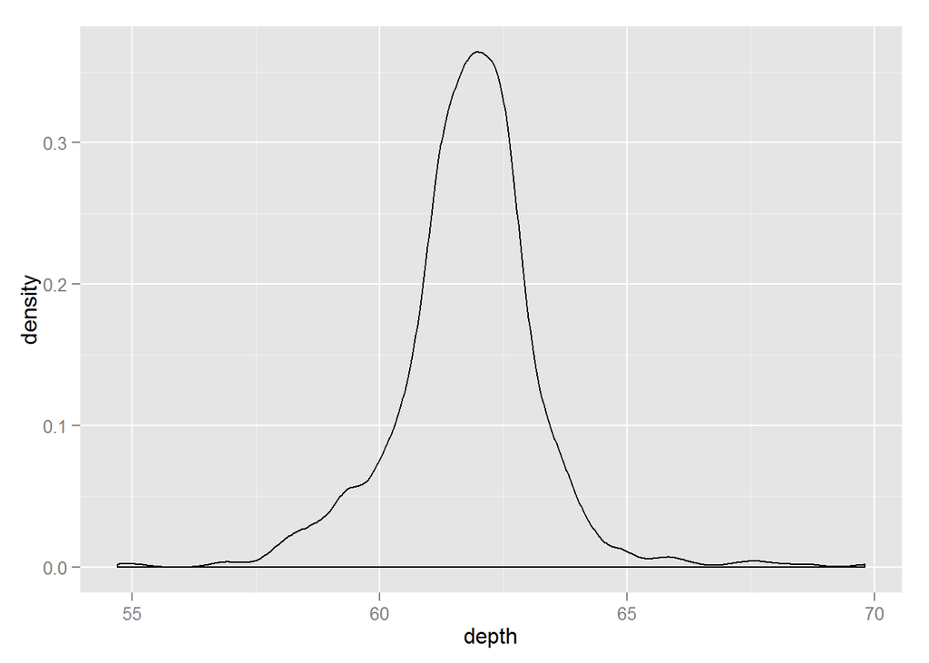

```r
qplot(x=depth, data=dsmall, geom="density")
```

### Histograms with density plots overlaid

Often is is more helpful to have the density (or kernal density) plot *on top of* a histogram plot.

#### Base graphics

Since the height of the bars in a histogram default to showing the frequency of records in the data set within that bin, we need to 1) scale the height so that it’s a *relative frequency*, and then use the `lines()` function to add a `density()` line on top.

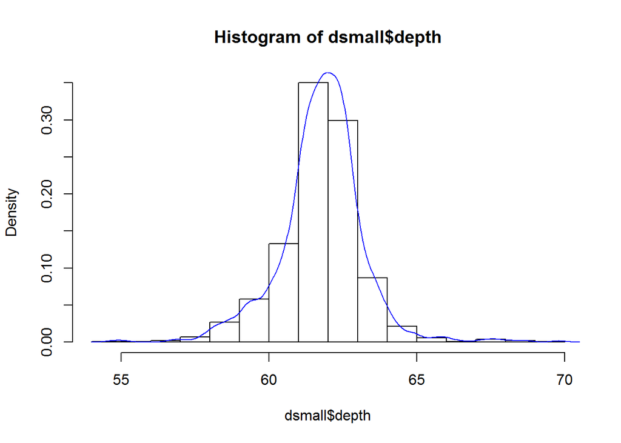

```r
hist(dsmall$depth, prob=TRUE)
lines(density(dsmall$depth), col="blue")
```

#### Ggplot2

This level of customization can’t be achieved using `qplot`, but it’s not that hard using `ggplot`. The syntax starts the same, we’ll add a new geom, `geom_density` and color the line blue. Then we add the histogram geom using `geom_histogram` but must specify that the y axis should be on the density, not frequency, scale. Note that this has to go inside the aestetic statement `aes()`. I’m also going to get rid of the fill by using `NA` so it doesn’t plot over the density line.

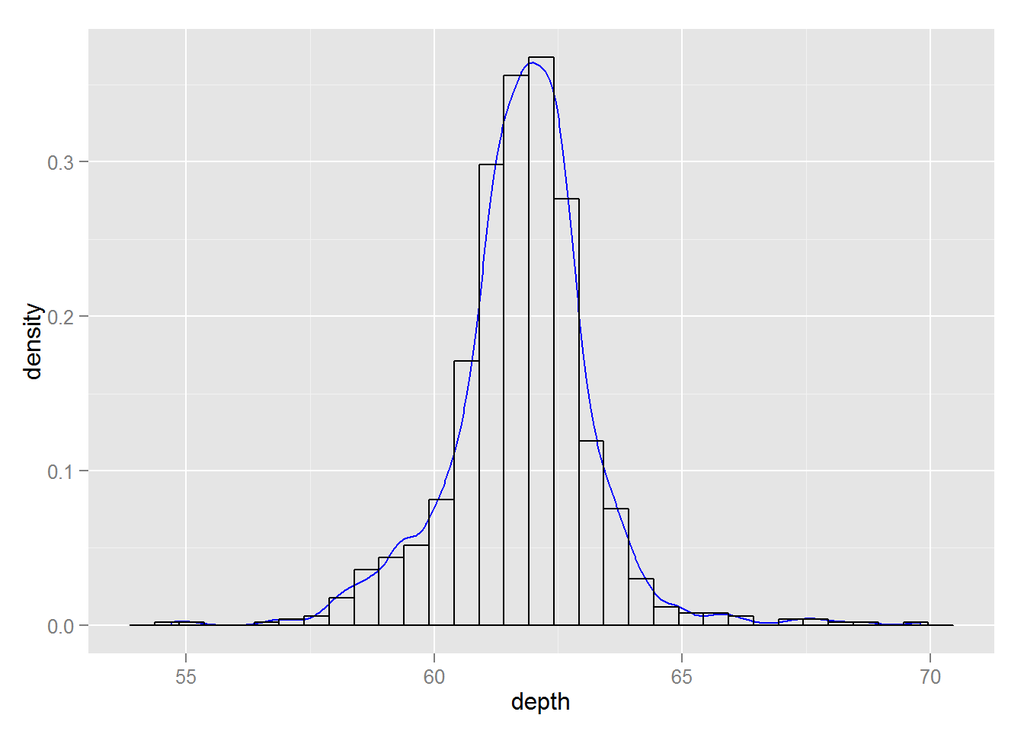

```r
ggplot(dsmall, aes(x=depth)) + geom_density(col="blue") +
  geom_histogram(aes(y=..density..), colour="black", fill=NA)
```

### Boxplots

Another very common way to visualize the distribution of a continuous variable is using a boxplot. Boxplots are useful for quickly identifying where the bulk of your data lie. R specifically draws a “modified” boxplot where values that are considered outliers are plotted as dots.

#### Base Graphics

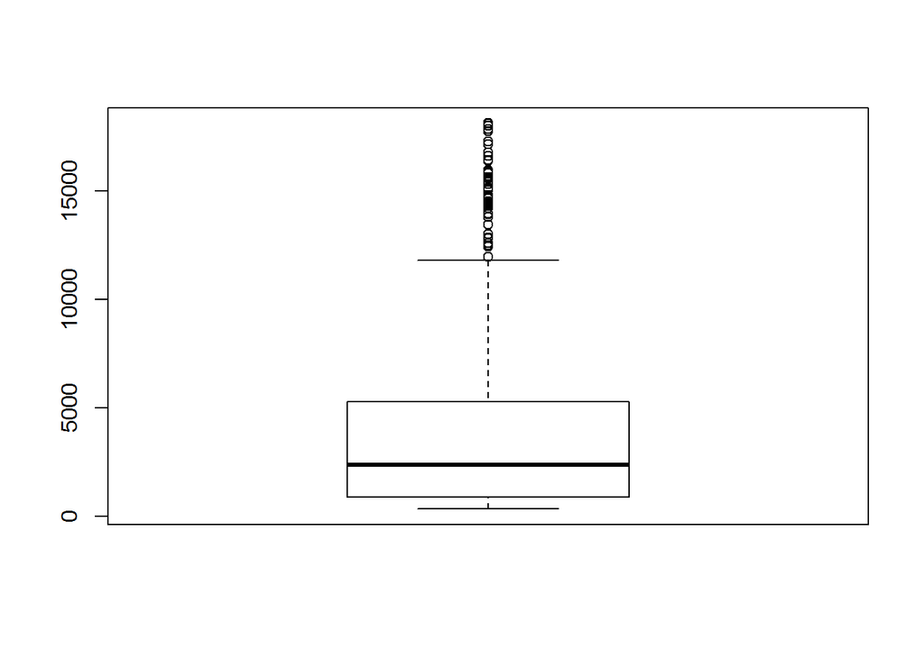

```r
boxplot(dsmall$price)
```

Notice that the only axis labeled is the y=axis. Like a dotplot the x axis, or “width”, of the boxplot is meaningless here. We can make the axis more readable by flipping the plot on it’s side.

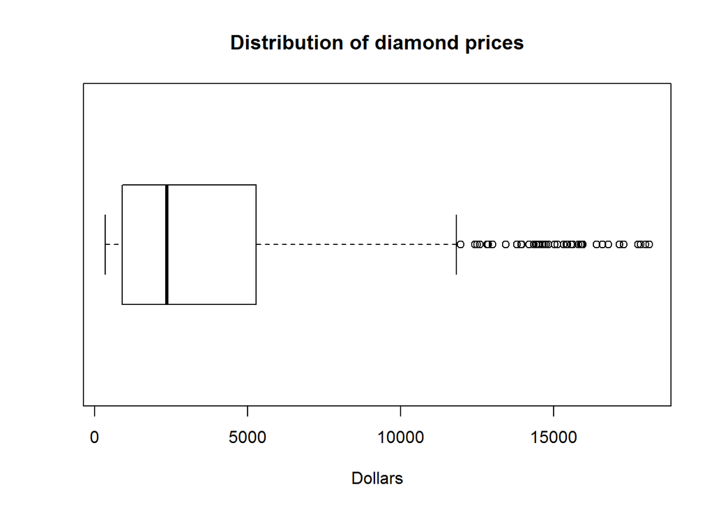

```r
boxplot(dsmall$price, horizontal = TRUE, main="Distribution of diamond prices", xlab="Dollars")
```

Horizontal is a bit easier to read in my opinion. What about ggplot? ggplot doesn’t do univariate boxplots (that I can easily figure out.) We’ll come back to grouped boxplots when we discuss plotting the relationship between a continuous and categorical variable.

## Normal QQ plots

The last useful plot that we will do on a single continuous variable is to assess the *normality* of the distribution. Basically how close the data follows a normal distribution.

#### Base graphics

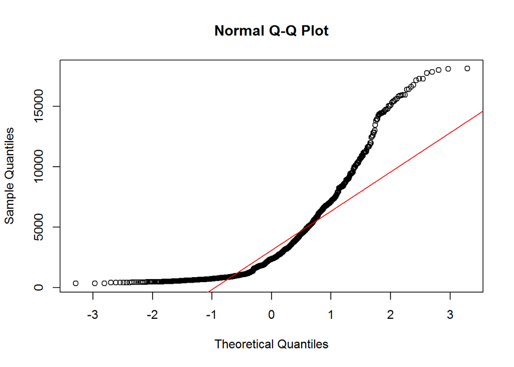

```r
qqnorm(dsmall$price)
qqline(dsmall$price, col="red")
```

The line I make red because it is a reference line. The closer the points are to following this line, the more “normal” the shape of the distribution is. Price has some pretty strong deviation away from that line. Below I have plotted what a normal distribution looks like as an example of a “perfect” fit.

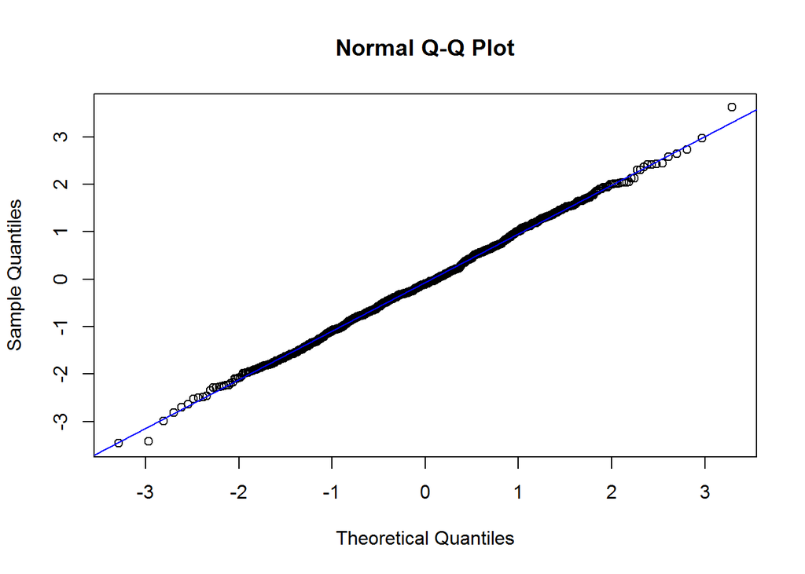

```r
z <- rnorm(1000)
qqnorm(z)
qqline(z, col="blue")
```

#### ggplot

Its much harder to create a QQplot using ggplot so we are going to skip it.

# Two numeric variables

### Scatterplot

The most common method of visualizing the relationship between two continuous variables is by using a scatterplot.

#### Base graphics

Back to the `plot()` command.

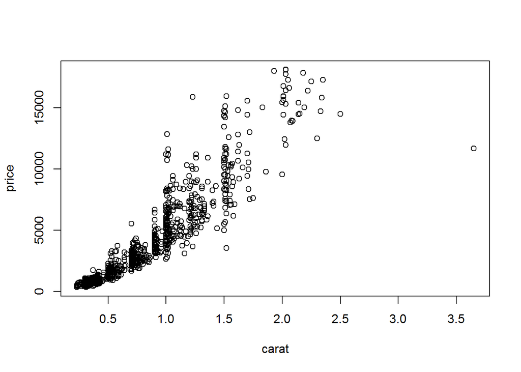

```r
plot(price~carat, data=dsmall)
```

Looks like for the most part as the carat value increases so does price. That makes sense.

#### ggplot

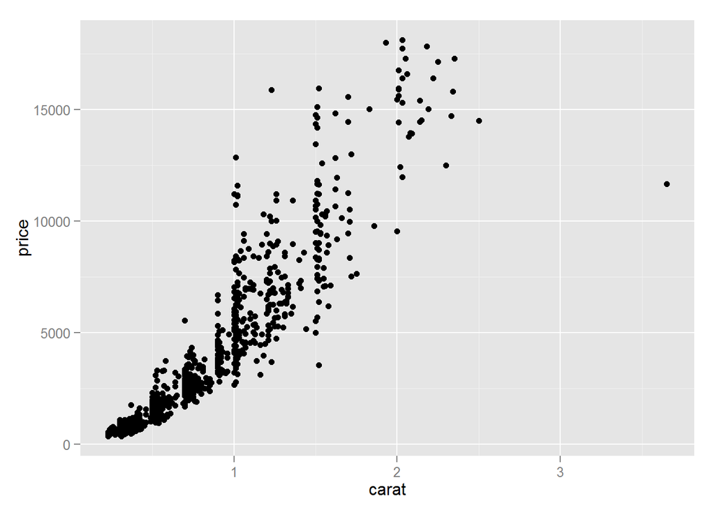

```r
qplot(x=carat, y=price, data=dsmall, geom='point')
```

Or alternatively we can use the `ggplot` argument with `geom_point()`.

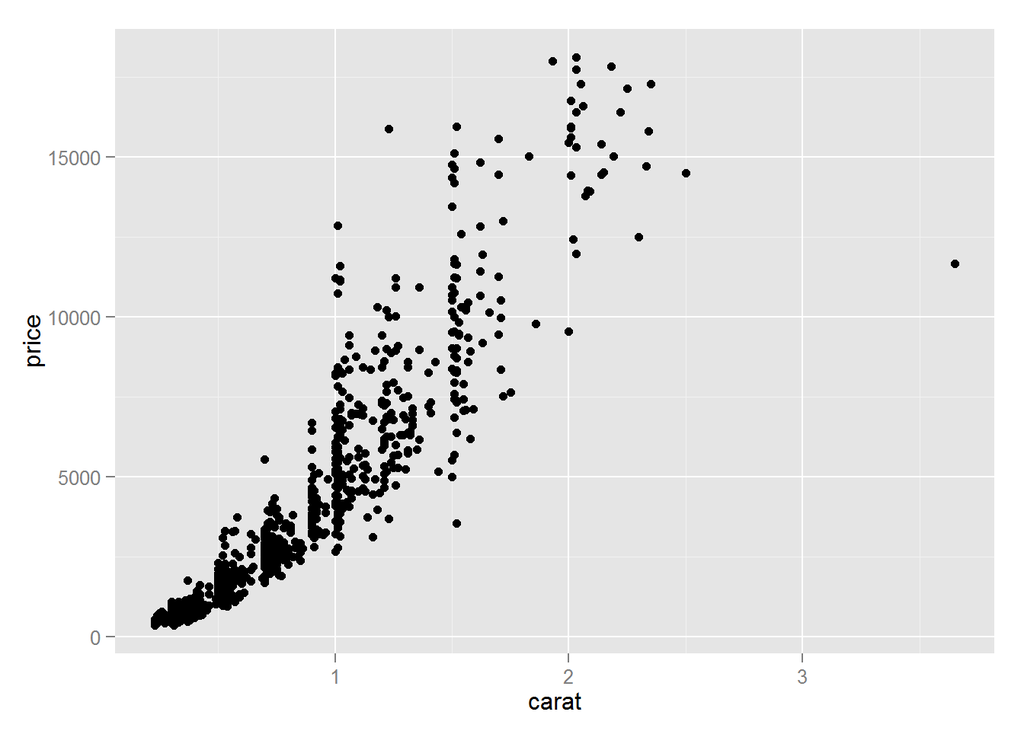

```r
ggplot(dsmall, aes(x=carat, y=price)) + geom_point()
```